# Zoop multivariate

Matt Brousil

2020-02-03

### Multivariate zooplankton exploration

A script for zooplankton community analysis using the “taxa” groupings from the NPS dataset.

```r
library(tidyverse)
library(readxl)
library(vegan)
library(labdsv)
```

```r
library(kableExtra)
library(viridis)
library(visdat)
library(corrplot)
library(psych)
library(ggvegan)
library(janitor)
library(ggpubr)
```

#### 1. Load the data and do some prep. (E.g., not sure what’s going on with row 1487).

```r
bigjoin <- readRDS(file = "../data/analysis_outputs/bigjoin.rds")
zoop <- read_excel("../data/NCCN_Zoops_Combined_For_FCA_May_2019.xlsx")
#  Prep data
zoop[1487, "Taxa"] <- "ROT"
zoop[1487, "Taxonid"] <- 5

# Name matching table
match_sites <- readRDS(file = file.path("..",
                                        "data",
                                        "name_site_matches.rds"))

# Crosswalk common names for sites to site_codes
zoop <- left_join(x = zoop, y = match_sites,
                  by = c("Lake" = "old_name")) %>%
  clean_names()

# Remove copepodites and nauplii from the dataset per MM suggestion
zoop_orig <- zoop

zoop <- zoop %>%
  filter(!grepl(pattern = "copepodite", x = gen_sp),
         !grepl(pattern = "nauplii", x = gen_sp),
         taxa != "INS", taxa != "HAR")
```

#### 2. NMDS prep and plot

I turn the density measurements into proportions of each taxon per sample. Then filter out taxa providing <5% of a sample before making into a matrix.

```r
zoop_prop_taxa <- zoop %>%
  # Dropping Code for now b/c unclear what it means. Code != Taxa though.
  # Also dropping taxonid
  group_by(park, site_code, lake, year, taxa) %>%
  summarise(density = sum(density)) %>%
  group_by(park, site_code, year) %>%
  mutate(sum_density = sum(density, na.rm = T)) %>%
  ungroup() %>%
  mutate(prop_density = density / sum_density) %>%
  filter(prop_density >= .05)

# Add a row identifier column, turn into matrix
zoop_comm_matrix <- zoop_prop_taxa %>%
  mutate(park_site_year = paste0(park, "_", site_code, "_", year)) %>%
  select(park_site_year, taxa, prop_density) %>%
  data.frame() %>%
  matrify()
```

Should sum to 1 within rows: (isn’t exact…rounding issue?)

```r
head(zoop_comm_matrix)
```

```
##                      CLAD       COPE       ROT
## MORA_LH14_2009 0.13197520 0.00000000 0.8449956
## MORA_LH14_2010 0.26861702 0.14627660 0.5851064
## MORA_LH14_2011 0.39616858 0.05057471 0.5532567
## MORA_LH14_2012 0.00000000 0.00000000 0.9664430
## MORA_LH14_2013 0.10364546 0.00000000 0.8520372
## MORA_LH14_2014 0.07234383 0.00000000 0.8841431
```

```r
sum(zoop_comm_matrix[1, ])
```

```
## [1] 0.9769708
```

Scree plot for an NMDS

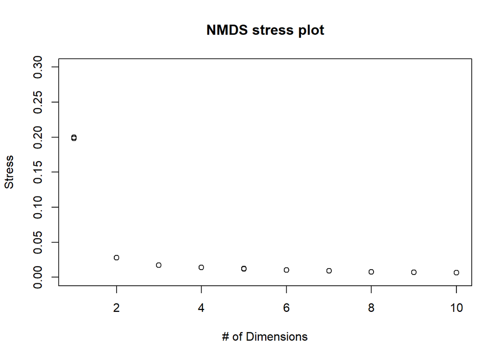

```r
# Adapted from https://ourcodingclub.github.io/2018/05/04/ordination.html
scree_plot <- function(x) { #where x is the name of the data frame variable
  plot(rep(1, 10),
       replicate(10, metaMDS(comm = x, distance = "bray", k = 1)$stress),
       xlim = c(1, 10),ylim = c(0, 0.30), xlab = "# of Dimensions",
       ylab = "Stress", main = "NMDS stress plot")
  for (i in 1:10) {
    points(rep(i + 1,10),replicate(10, metaMDS(x,  distance = "bray", k = i + 1)$stress))
  }
}

scree_plot(zoop_comm_matrix)
```

```r
nmds_2 <- metaMDS(comm = zoop_comm_matrix, distance = "bray", k = 2, trymax = 100)
```

```r
nmds_2
```

```
##
## Call:
## metaMDS(comm = zoop_comm_matrix, distance = "bray", k = 2, trymax = 100)
##
## global Multidimensional Scaling using monoMDS
##
## Data:     zoop_comm_matrix
## Distance: bray
##
## Dimensions: 2
## Stress:     0.02795414
## Stress type 1, weak ties
## Two convergent solutions found after 67 tries
## Scaling: centring, PC rotation, halfchange scaling
## Species: expanded scores based on 'zoop_comm_matrix'
```

#### Let’s plot it:

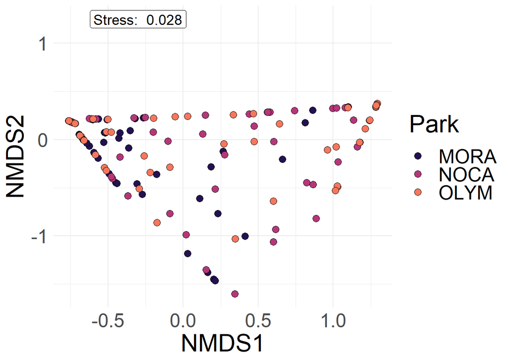

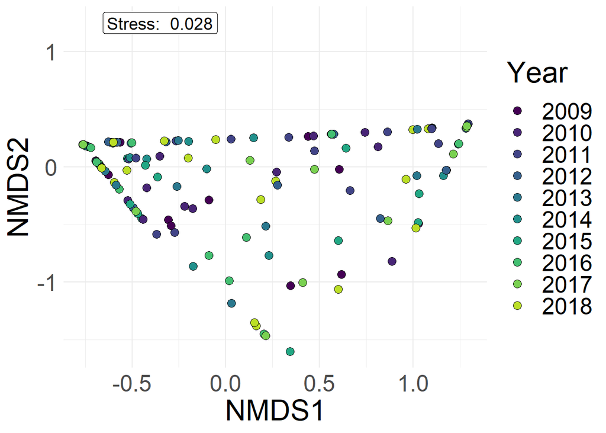

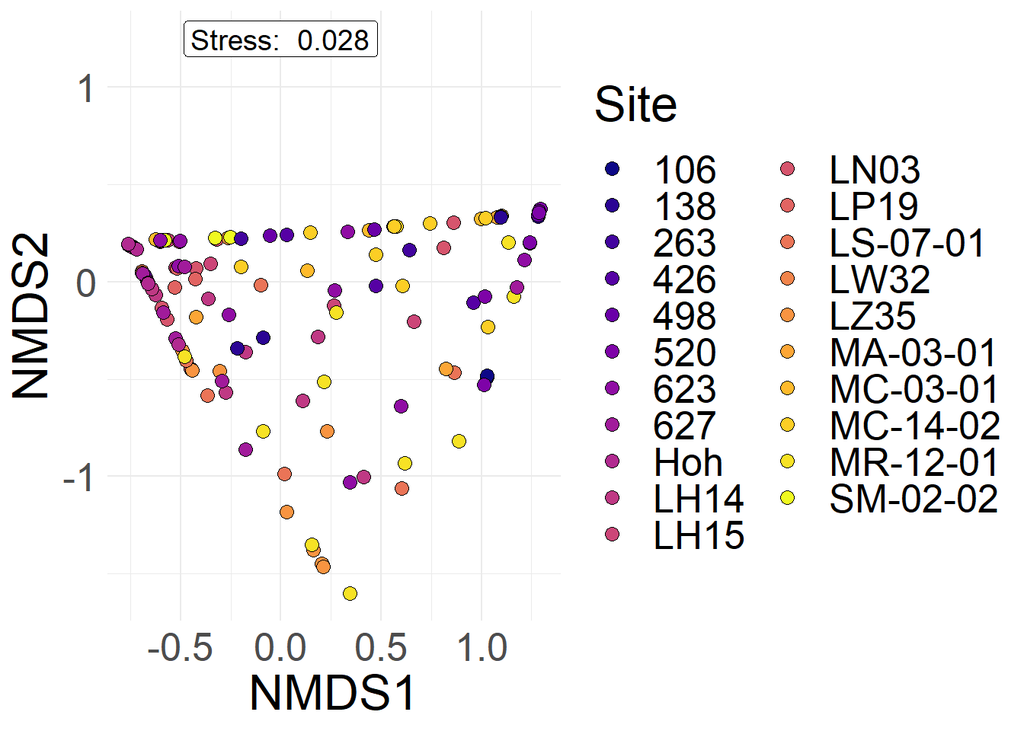

```r
zoop_scomm_ids <- rownames_to_column(zoop_comm_matrix) %>%
  separate(col = rowname, into = c("park", "site", "year"), sep = "_")

zoop_permanova <- adonis(formula = select(zoop_scomm_ids, CLAD:ROT) ~ year + site + park,
                         data = zoop_scomm_ids, method = "bray")

zoop_permanova
```

```
##
## Call:
## adonis(formula = select(zoop_scomm_ids, CLAD:ROT) ~ year + site +      park, data = zoop_scomm_ids, method = "bray")
##
## Permutation: free
## Number of permutations: 999
##
## Terms added sequentially (first to last)
##
##            Df SumsOfSqs MeanSqs F.Model      R2 Pr(>F)
## year        9     1.410 0.15666  1.3303 0.03584  0.188
## site       20    17.323 0.86614  7.3546 0.44031  0.001 ***
## Residuals 175    20.609 0.11777         0.52385
## Total     204    39.342                 1.00000
## ---
## Signif. codes:  0 '***' 0.001 '**' 0.01 '*' 0.05 '.' 0.1 ' ' 1
```

#### 3. Make some univariate plots to look at similar metrics

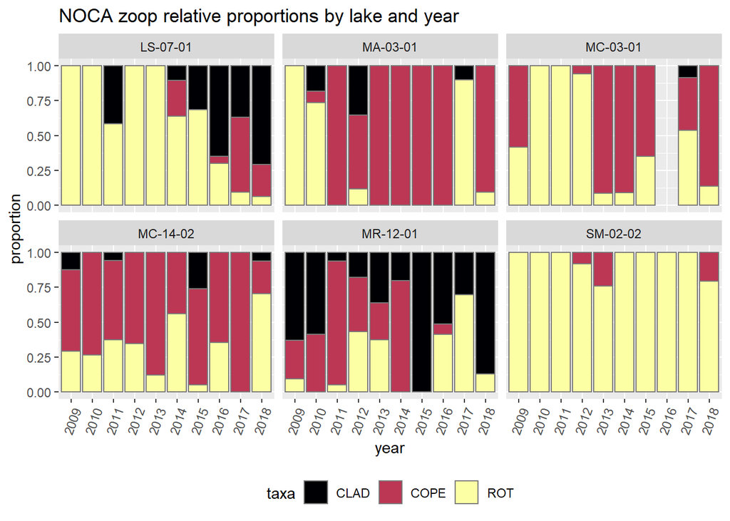

```r
# Reshape the proportion community data into a useful data frame for ggplot2
zoop_props <- as.data.frame(zoop_comm_matrix) %>%
  bind_cols(park_site_year = row.names(.), .) %>%
  separate(data = ., col = park_site_year, into = c("park", "site", "year"),
           sep = "_") %>%
  gather(key = taxa, value = proportion, -park, -site, -year)

noca_zoop_uni_plot <- zoop_props %>%
  filter(park == "NOCA") %>%
  ggplot() +
  geom_bar(aes(x = year, y = proportion, fill = taxa),
           stat = "identity", position = "fill", color = "gray48") +
  facet_wrap(. ~ site) +
  theme(axis.text.x = element_text(angle = 70, hjust = 1),
        legend.position = "bottom") +
  scale_fill_viridis_d(option = "inferno")
```

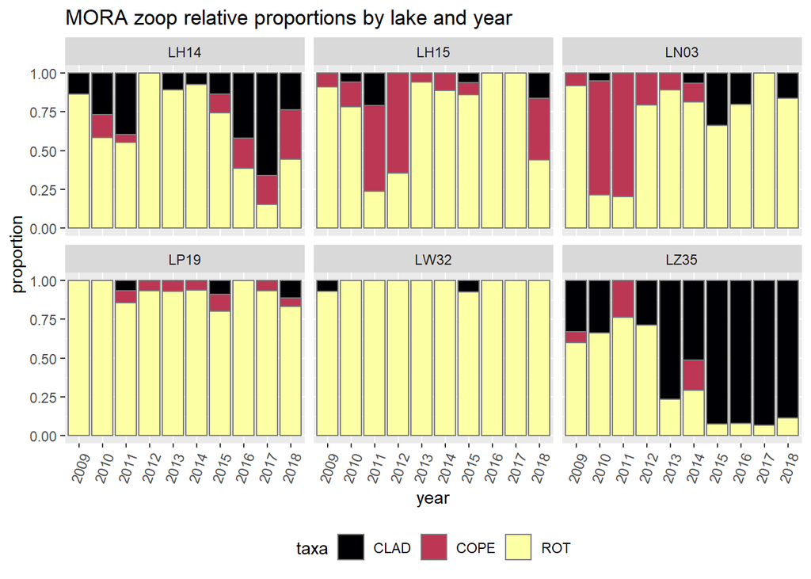

```r
mora_zoop_uni_plot <- zoop_props %>%
  filter(park == "MORA") %>%
  ggplot() +
  geom_bar(aes(x = year, y = proportion, fill = taxa),
           stat = "identity", position = "fill", color = "gray48") +
  facet_wrap(. ~ site) +
  theme(axis.text.x = element_text(angle = 70, hjust = 1),
        legend.position = "bottom") +
  scale_fill_viridis_d(option = "inferno")
```

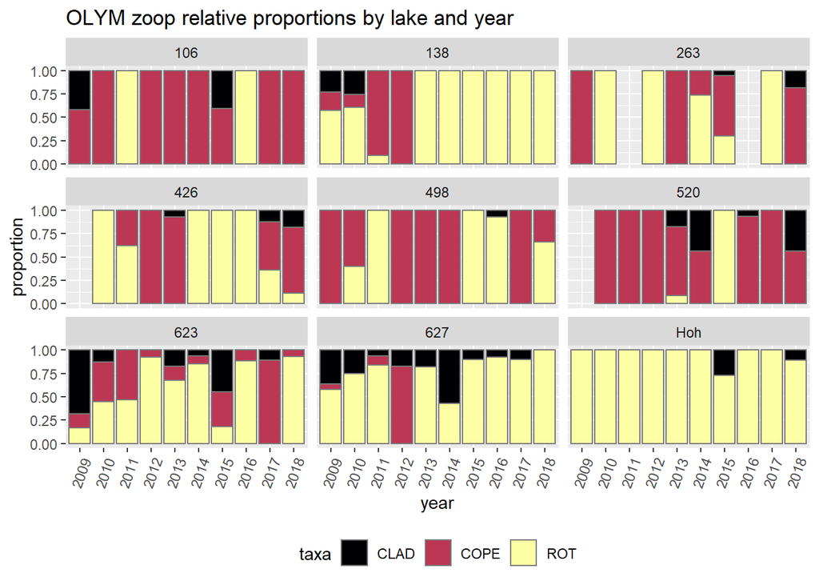

```r
olym_zoop_uni_plot <- zoop_props %>%
  filter(park == "OLYM") %>%
  ggplot() +
  geom_bar(aes(x = year, y = proportion, fill = taxa),
           stat = "identity", position = "fill", color = "gray48") +
  facet_wrap(. ~ site) +
  theme(axis.text.x = element_text(angle = 70, hjust = 1),
        legend.position = "bottom") +
  scale_fill_viridis_d(option = "inferno")
```

#### Distance-based redundancy analysis (dbRDA)

vegan::capscale()/dbRDA() documentation: *Distance-based redundancy analysis (dbRDA) is an ordination method similar to Redundancy Analysis (rda), but it allows non-Euclidean dissimilarity indices, such as Manhattan or Bray–Curtis distance. Despite this non-Euclidean feature, the analysis is strictly linear and metric. If called with Euclidean distance, the results are identical to rda, but dbRDA will be less efficient. Functions capscale and dbrda are constrained versions of metric scaling, a.k.a. principal coordinates analysis, which are based on the Euclidean distance but can be used, and are more useful, with other dissimilarity measures. The functions can also perform unconstrained principal coordinates analysis, optionally using extended dissimilarities.*

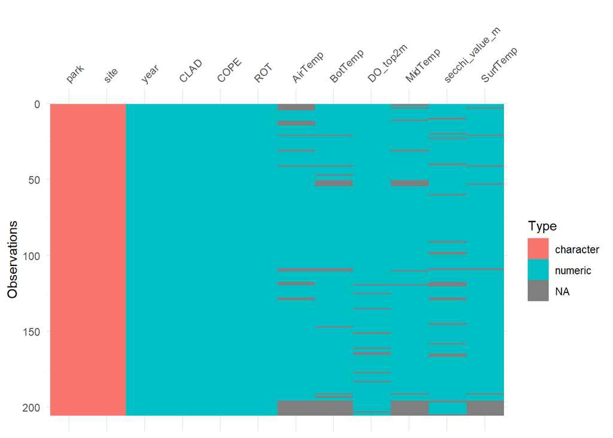

```r
zoop_scomm_ids <- zoop_scomm_ids %>%
  mutate(year = as.numeric(year))

yearly_bigjoin <- bigjoin %>%
  filter(variable %in% c("secchi_value_m", "AirTemp", "BotTemp",
                         "MidTemp", "SurfTemp", "DO_top2m")) %>%
  select(park_code, site_code, event_year, variable, value) %>%
  unique() %>%
  spread(key = variable, value = value)

# Join the zoops to yearly_bigjoin bc some data will be NA: both datasets
# should have corresponding rows
yearly_bigjoin_zoop <- inner_join(x = zoop_scomm_ids, y = yearly_bigjoin,
                                  by = c("park" = "park_code",
                                         "site" = "site_code",
                                         "year" = "event_year"))

vis_dat(x = yearly_bigjoin_zoop)
```

Now look at env variable correlations, but first check for and remove NAs

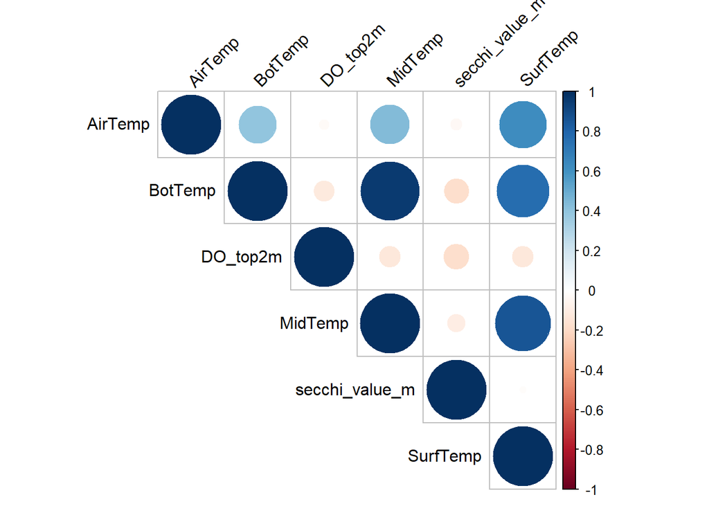

```r
# Down some rows after removing NAs...
yearly_bigjoin_zoop <- na.omit(yearly_bigjoin_zoop)

corrplot(cor(select(yearly_bigjoin_zoop, AirTemp:SurfTemp)), type = "upper",
         tl.col = "black", tl.srt = 45)
```

```r
# corr.test(x = select(yearly_bigjoin_zoop, AirTemp:SurfaceTemp))
```

How about keep SurfTemp, drop other temps?

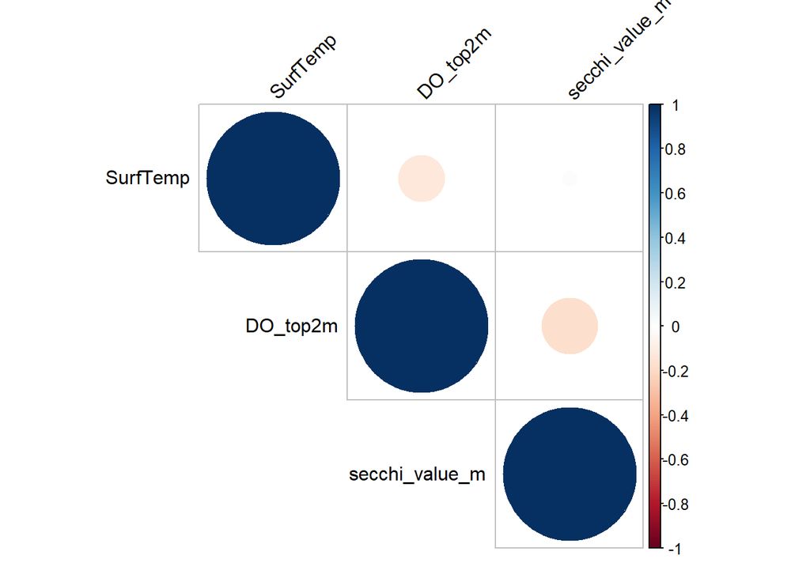

```r
corrplot(cor(select(yearly_bigjoin_zoop, SurfTemp, DO_top2m, secchi_value_m)),
         type = "upper", tl.col = "black", tl.srt = 45)
```

```r
corr.test(x = select(yearly_bigjoin_zoop, SurfTemp, DO_top2m, secchi_value_m))
```

```
## Call:corr.test(x = select(yearly_bigjoin_zoop, SurfTemp, DO_top2m,
##     secchi_value_m))
## Correlation matrix
##                SurfTemp DO_top2m secchi_value_m
## SurfTemp           1.00    -0.12          -0.01
## DO_top2m          -0.12     1.00          -0.18
## secchi_value_m    -0.01    -0.18           1.00
## Sample Size
## [1] 150
## Probability values (Entries above the diagonal are adjusted for multiple tests.)
##                SurfTemp DO_top2m secchi_value_m
## SurfTemp           0.00     0.27           0.87
## DO_top2m           0.13     0.00           0.09
## secchi_value_m     0.87     0.03           0.00
##
##  To see confidence intervals of the correlations, print with the short=FALSE option
```

Looks like secchi and DO are correlated significantly, but the correlation is weak. I keep both for now.

Run dbRDA. Note that it doesn’t provide species score (capscale() does).

**Note** that in joining in the environmental data and removing NAs, we’ve lost 55 rows (27%) of data compared with the matrix used for producing the previous nmds output.

```r
zoop_dbrda <- dbrda(formula = select(yearly_bigjoin_zoop, CLAD:ROT) ~
                      SurfTemp + DO_top2m + secchi_value_m, data = yearly_bigjoin_zoop,
                    distance = "bray")

zoop_dbrda
```

```
## Call: dbrda(formula = select(yearly_bigjoin_zoop, CLAD:ROT) ~ SurfTemp
## + DO_top2m + secchi_value_m, data = yearly_bigjoin_zoop, distance =
## "bray")
##
##                Inertia Proportion Rank RealDims
## Total         29.96380    1.00000
## Constrained    1.68168    0.05612    3        2
## Unconstrained 28.28212    0.94388   93       43
## Inertia is squared Bray distance
##
## Eigenvalues for constrained axes:
##  dbRDA1  dbRDA2 idbRDA1
##  1.6150  0.0827 -0.0160
##
## Eigenvalues for unconstrained axes:
##   MDS1   MDS2   MDS3   MDS4   MDS5   MDS6   MDS7   MDS8
## 22.200  6.318  1.154  0.474  0.301  0.233  0.174  0.118
## (Showing 8 of 93 unconstrained eigenvalues)
```

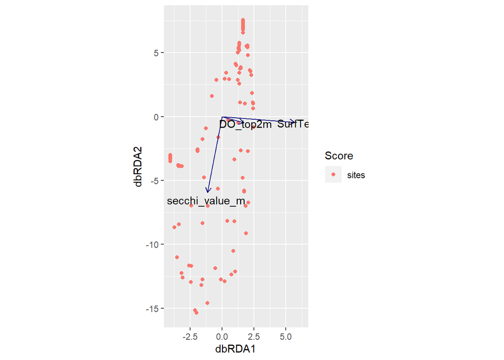

```r
autoplot(zoop_dbrda)
```

The first dbRDA axis accounts for 96.04% of the variation. The second dbRDA axis accounts for 4.92% of the variation.

```r
# https://sites.ualberta.ca/~ahamann/teaching/renr690/Lab9b.pdf
anova(zoop_dbrda)
```

```
## Permutation test for dbrda under reduced model
## Permutation: free
## Number of permutations: 999
##
## Model: dbrda(formula = select(yearly_bigjoin_zoop, CLAD:ROT) ~ SurfTemp + DO_top2m + secchi_value_m, data = yearly_bigjoin_zoop, distance = "bray")
##           Df SumOfSqs      F Pr(>F)
## Model      3   1.6817 2.8938   0.02 *
## Residual 146  28.2821
## ---
## Signif. codes:  0 '***' 0.001 '**' 0.01 '*' 0.05 '.' 0.1 ' ' 1
```

```r
# anova(zoop_dbrda, by = "axis", perm.max = 999) # Won't run bc negative eigenvalues
anova(zoop_dbrda, by = "terms", perm.max = 999)
```

```
## Permutation test for dbrda under reduced model
## Terms added sequentially (first to last)
## Permutation: free
## Number of permutations: 999
##
## Model: dbrda(formula = select(yearly_bigjoin_zoop, CLAD:ROT) ~ SurfTemp + DO_top2m + secchi_value_m, data = yearly_bigjoin_zoop, distance = "bray")
##                 Df SumOfSqs      F Pr(>F)
## SurfTemp         1   1.3522 6.9804  0.009 **
## DO_top2m         1   0.2310 1.1924  0.309
## secchi_value_m   1   0.0985 0.5085  0.566
## Residual       146  28.2821
## ---
## Signif. codes:  0 '***' 0.001 '**' 0.01 '*' 0.05 '.' 0.1 ' ' 1
```

Run another NDMS, this time on the version of the community matrix that made it into the dbRDA. It’s a subset of the full one used for the earlier nmds_2:

```r
subset_nmds <- metaMDS(comm = select(yearly_bigjoin_zoop, CLAD:ROT),
                       distance = "bray", k = 2, trymax = 100)
```

[output not shown]